# **Assignment 9: Introduction To CNN Models**

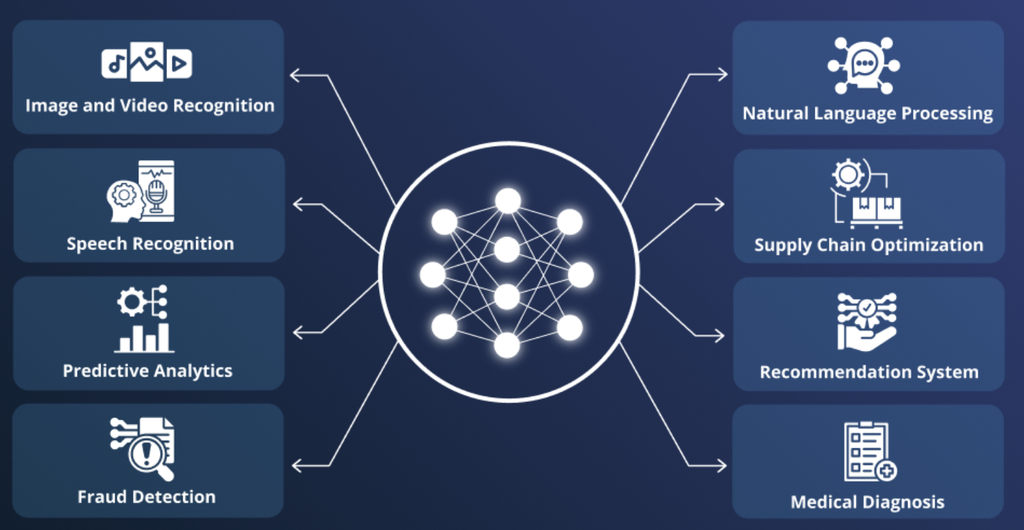

# **Image Classification**

**Goal:** Build a DL-based for Digit Classification on Street View House Numbers dataset.

**Street View House Numbers (SVHN**) is a digit classification benchmark dataset that contains 600,000 32×32 RGB images of printed digits (from 0 to 9) cropped from pictures of house number plates. The cropped images are centered in the digit of interest, but nearby digits and other distractors are kept in the image. SVHN has three sets: training, testing sets and an extra set with 530,000 images that are less difficult and can be used for helping with the training process.

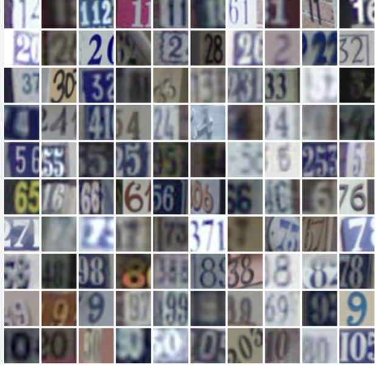

**Question 1:** Load the images from file. Present the number of training, testing and Validation samples. Also, show the Image Dimensions, labels, and image formats.

```python
# Imports and Device Setup
import numpy as np
import matplotlib.pyplot as plt
import time
import os
from PIL import Image

# PyTorch imports
import torch
import torch.nn as nn
import torch.optim as optim
from torch.utils.data import Dataset, DataLoader
import torchvision.transforms as transforms
from sklearn.metrics import classification_report, f1_score, precision_score, recall_score

# Device configuration for M3 MacBook
if torch.backends.mps.is_available():
    device = torch.device("mps")
```

```
Loading data from .mat files...
Training samples: 73257
Testing samples: 26032
Unique labels: [0 1 2 3 4 5 6 7 8 9]
Label distribution: [ 4948 13861 10585  8497  7458  6882  5727  5595  5045  4659]
Training samples: 73257
Testing samples: 26032
Image dimensions: (3, 32, 32) (C, H, W)
Image format: RGB (3 channels)
Number of classes: 10
Class labels: [0 1 2 3 4 5 6 7 8 9]
Data type: uint8
Value range: [0, 255]
```

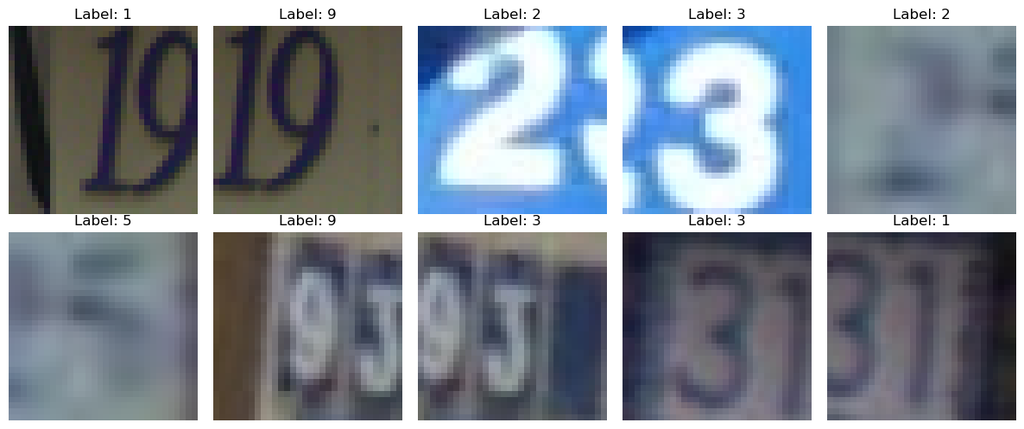

```python
from scipy.io import loadmat

def load_svhn_data():
    """Load SVHN dataset from .mat files"""
    print("Loading data from .mat files...")

    train_data = loadmat('archive/train_32x32.mat')
    test_data = loadmat('archive/test_32x32.mat')

    X_train = train_data['X']
    y_train = train_data['y']
    X_test = test_data['X']
    y_test = test_data['y']

    X_train = np.transpose(X_train, (3, 2, 0, 1))
    X_test = np.transpose(X_test, (3, 2, 0, 1))

    y_train[y_train == 10] = 0
    y_test[y_test == 10] = 0
    y_train = y_train.flatten()
    y_test = y_test.flatten()

    print(f"Training samples: {X_train.shape[0]}")
    print(f"Testing samples: {X_test.shape[0]}")
    print(f"Unique labels: {np.unique(y_train)}")
    print(f"Label distribution: {np.bincount(y_train)}")

    return X_train, y_train, X_test, y_test



def explore_data(X_train, y_train, X_test, y_test):
    print(f"Training samples: {X_train.shape[0]}")
    print(f"Testing samples: {X_test.shape[0]}")
    print(f"Image dimensions: {X_train.shape[1:]} (C, H, W)")
    print(f"Image format: RGB (3 channels)")
    print(f"Number of classes: {len(np.unique(y_train))}")
    print(f"Class labels: {np.unique(y_train)}")
    print(f"Data type: {X_train.dtype}")
    print(f"Value range: [{X_train.min()}, {X_train.max()}]")


    fig, axes = plt.subplots(2, 5, figsize=(12, 5))
    for i, ax in enumerate(axes.flat):
        img = np.transpose(X_train[i], (1, 2, 0))
        ax.imshow(img.astype('uint8'))
        ax.set_title(f"Label: {y_train[i]}")
        ax.axis('off')
    plt.tight_layout()
    plt.show()

X_train, y_train, X_test, y_test = load_svhn_data()
explore_data(X_train, y_train, X_test, y_test)
```

**Question 2:** Using Keras or PyTorch, clean, normalize, and re-shape the data for the model input.

```python
def preprocess_data(X_train, y_train, X_test, y_test):
    print("\nPreprocessing data...")

    X_train = X_train.astype(np.float32)
    X_test = X_test.astype(np.float32)

    print(f"Before normalization - Range: [{X_train.min():.1f}, {X_train.max():.1f}]")

    # Normalize to [0, 1]
    X_train = X_train / 255.0
    X_test = X_test / 255.0

    # Standardization (mean=0, std=1)
    mean = X_train.mean(axis=(0, 2, 3), keepdims=True)
    std = X_train.std(axis=(0, 2, 3), keepdims=True)
    X_train = (X_train - mean) / (std + 1e-7)
    X_test = (X_test - mean) / (std + 1e-7)

    print("\nData Preprocessing Complete:")
    print(f"Training shape: {X_train.shape}")
    print(f"Testing shape: {X_test.shape}")
    print(f"After normalization - Range: [{X_train.min():.3f}, {X_train.max():.3f}]")
    print(f"Mean per channel: {mean.flatten()}")
    print(f"Std per channel: {std.flatten()}")

    return X_train, X_test, mean, std

# Preprocess the data
X_train, X_test, mean, std = preprocess_data(X_train, y_train, X_test, y_test)
```

```
Preprocessing data...
Before normalization - Range: [0.0, 255.0]

Data Preprocessing Complete:
Training shape: (73257, 3, 32, 32)
Testing shape: (26032, 3, 32, 32)
After normalization - Range: [-2.400, 2.840]
Mean per channel: [0.43768454 0.44376847 0.4728039 ]
Std per channel: [0.19803019 0.20101567 0.19703582]
```

**Question 3:** Data augmentation in deep learning is a technique to artificially expand a dataset by creating modified copies of existing data, thereby increasing the size and diversity of the training set. This process improves model performance by enhancing generalizability and reducing overfitting, as it allows the model to encounter a wider range of real-world variations. Common methods include geometric transformations (like image rotation and flips), color space transformations (adjusting brightness, contrast), and random erasing.

Apply any Data Augmentation to increase the variety of training examples, lead to help the model generalize better. Provide the description of apparoch and the importance of data augmentation in DL process.

```python
class SVHNAugmentedDataset(Dataset):

    def __init__(self, X, y, augment=True):
        self.X = torch.FloatTensor(X)
        self.y = torch.LongTensor(y)
        self.augment = augment

        # Define augmentation transforms
        if augment:
            self.transform = transforms.Compose([
                transforms.RandomRotation(15),
                transforms.RandomAffine(degrees=0, translate=(0.1, 0.1)),
                transforms.ColorJitter(brightness=0.2, contrast=0.2, saturation=0.2),
                transforms.RandomErasing(p=0.3, scale=(0.02, 0.15))
            ])
        else:
            self.transform = None

    def __len__(self):
        return len(self.X)

    def __getitem__(self, idx):
        x, y = self.X[idx], self.y[idx]

        if self.augment and self.transform:
            x = self.transform(x)

        return x, y

print("Data augmentation class created successfully!")
```

```
Data augmentation class created successfully!
```

```
Demonstrating augmentation on sample images...
```

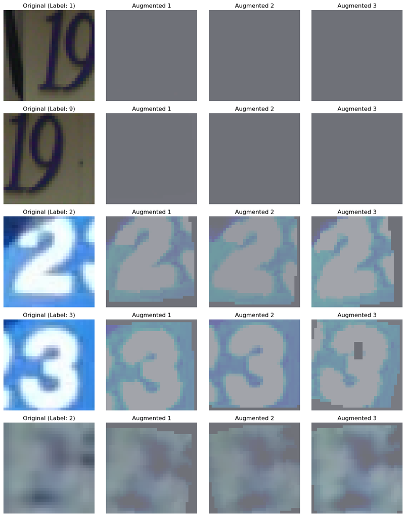

```
Augmentation examples saved as 'augmentation_examples.png'
```

```python
# ===================================
# CELL 7: Question 3 - Discussion and Demonstration
# ===================================


# Demonstrate augmentation
print("\nDemonstrating augmentation on sample images...")
sample_dataset = SVHNAugmentedDataset(X_train[:5], y_train[:5], augment=True)

fig, axes = plt.subplots(5, 4, figsize=(12, 15))
for i in range(5):
    # Original - need to denormalize for display
    original = X_train[i]
    # Denormalize
    original_display = original * std.squeeze()[:, np.newaxis, np.newaxis] + mean.squeeze()[:, np.newaxis, np.newaxis]
    original_display = np.clip(original_display, 0, 1)
    axes[i, 0].imshow(np.transpose(original_display, (1, 2, 0)))
    axes[i, 0].set_title(f'Original (Label: {y_train[i]})')
    axes[i, 0].axis('off')

    # Augmented versions
    for j in range(1, 4):
        aug_img, _ = sample_dataset[i]
        # Denormalize augmented
        aug_display = aug_img.numpy() * std.squeeze()[:, np.newaxis, np.newaxis] + mean.squeeze()[:, np.newaxis, np.newaxis]
        aug_display = np.clip(aug_display, 0, 1)
        axes[i, j].imshow(np.transpose(aug_display, (1, 2, 0)))
        axes[i, j].set_title(f'Augmented {j}')
        axes[i, j].axis('off')

plt.tight_layout()
plt.savefig('augmentation_examples.png')
plt.show()
print("Augmentation examples saved as 'augmentation_examples.png'")
```

**Question 4:** Normalize, reshape, and encode the data to make it ready for classification. Also, what is data batching and why we need it? perform it.

```python
def create_dataloaders(X_train, y_train, X_test, y_test, batch_size=128):
    """Create data loaders with batching"""

    # Create datasets
    train_dataset = SVHNAugmentedDataset(X_train, y_train, augment=True)
    test_dataset = SVHNAugmentedDataset(X_test, y_test, augment=False)

    # Create data loaders
    train_loader = DataLoader(train_dataset, batch_size=batch_size,
                             shuffle=True, num_workers=0)
    test_loader = DataLoader(test_dataset, batch_size=batch_size,
                            shuffle=False, num_workers=0)
    return train_loader, test_loader

# Create data loaders
train_loader, test_loader = create_dataloaders(X_train, y_train, X_test, y_test, batch_size=128)
```

**Question 5:** Using Keras/PyTorch, implement the Simple CNN and AlexNet to classify different didgits. Provide the details of the proposed architecture for both CNN and AlexNet.

```python
# Question 5 - Simple CNN Architecture


class SimpleCNN(nn.Module):


    def __init__(self):
        super(SimpleCNN, self).__init__()

        # Convolutional layers
        self.conv1 = nn.Sequential(
            nn.Conv2d(3, 32, kernel_size=3, padding=1),
            nn.BatchNorm2d(32),
            nn.ReLU(),
            nn.MaxPool2d(2, 2)
        )

        self.conv2 = nn.Sequential(
            nn.Conv2d(32, 64, kernel_size=3, padding=1),
            nn.BatchNorm2d(64),
            nn.ReLU(),
            nn.MaxPool2d(2, 2)
        )

        self.conv3 = nn.Sequential(
            nn.Conv2d(64, 128, kernel_size=3, padding=1),
            nn.BatchNorm2d(128),
            nn.ReLU(),
            nn.MaxPool2d(2, 2)
        )

        # Fully connected layers
        self.fc = nn.Sequential(
            nn.Flatten(),
            nn.Linear(128 * 4 * 4, 256),
            nn.ReLU(),
            nn.Dropout(0.5),
            nn.Linear(256, 128),
            nn.ReLU(),
            nn.Dropout(0.3),
            nn.Linear(128, 10)
        )

    def forward(self, x):
        x = self.conv1(x)
        x = self.conv2(x)
        x = self.conv3(x)
        x = self.fc(x)
        return x

# Create Simple CNN
simple_cnn = SimpleCNN().to(device)
print("Simple CNN created successfully!")
```

```
Simple CNN created successfully!
```

```python
# AlexNet Architecture


class AlexNet(nn.Module):


    def __init__(self):
        super(AlexNet, self).__init__()

        self.features = nn.Sequential(
            # Conv1
            nn.Conv2d(3, 64, kernel_size=3, stride=1, padding=1),
            nn.BatchNorm2d(64),
            nn.ReLU(inplace=True),
            nn.MaxPool2d(kernel_size=2, stride=2),

            # Conv2
            nn.Conv2d(64, 192, kernel_size=3, padding=1),
            nn.BatchNorm2d(192),
            nn.ReLU(inplace=True),
            nn.MaxPool2d(kernel_size=2, stride=2),

            # Conv3
            nn.Conv2d(192, 384, kernel_size=3, padding=1),
            nn.BatchNorm2d(384),
            nn.ReLU(inplace=True),

            # Conv4
            nn.Conv2d(384, 256, kernel_size=3, padding=1),
            nn.BatchNorm2d(256),
            nn.ReLU(inplace=True),

            # Conv5
            nn.Conv2d(256, 256, kernel_size=3, padding=1),
            nn.BatchNorm2d(256),
            nn.ReLU(inplace=True),
            nn.MaxPool2d(kernel_size=2, stride=2)
        )

        self.classifier = nn.Sequential(
            nn.Dropout(0.5),
            nn.Linear(256 * 4 * 4, 4096),
            nn.ReLU(inplace=True),
            nn.Dropout(0.5),
            nn.Linear(4096, 4096),
            nn.ReLU(inplace=True),
            nn.Linear(4096, 10)
        )

    def forward(self, x):
        x = self.features(x)
        x = torch.flatten(x, 1)
        x = self.classifier(x)
        return x

# Create AlexNet
alexnet = AlexNet().to(device)
print("AlexNet created successfully!")
```

```
AlexNet created successfully!
```

```python
def print_model_info(model, model_name):
    print(f"\n{'=' * 60}")
    print(f"{model_name} Architecture")
    print(f"{'=' * 60}")
    print(model)

    # Count parameters
    total_params = sum(p.numel() for p in model.parameters())
    trainable_params = sum(p.numel() for p in model.parameters() if p.requires_grad)

    print(f"\nTotal Parameters: {total_params:,}")
    print(f"Trainable Parameters: {trainable_params:,}")
    print(f"{'=' * 60}")

# Print architecture details
print_model_info(simple_cnn, "Simple CNN")
print_model_info(alexnet, "AlexNet")
```

```
============================================================
Simple CNN Architecture
============================================================
SimpleCNN(
  (conv1): Sequential(
    (0): Conv2d(3, 32, kernel_size=(3, 3), stride=(1, 1), padding=(1, 1))
    (1): BatchNorm2d(32, eps=1e-05, momentum=0.1, affine=True, track_running_stats=True)
    (2): ReLU()
    (3): MaxPool2d(kernel_size=2, stride=2, padding=0, dilation=1, ceil_mode=False)
  )
  (conv2): Sequential(
    (0): Conv2d(32, 64, kernel_size=(3, 3), stride=(1, 1), padding=(1, 1))
    (1): BatchNorm2d(64, eps=1e-05, momentum=0.1, affine=True, track_running_stats=True)
    (2): ReLU()
    (3): MaxPool2d(kernel_size=2, stride=2, padding=0, dilation=1, ceil_mode=False)
  )
  (conv3): Sequential(
    (0): Conv2d(64, 128, kernel_size=(3, 3), stride=(1, 1), padding=(1, 1))
    (1): BatchNorm2d(128, eps=1e-05, momentum=0.1, affine=True, track_running_stats=True)
    (2): ReLU()
    (3): MaxPool2d(kernel_size=2, stride=2, padding=0, dilation=1, ceil_mode=False)
  )
  (fc): Sequential(
    (0): Flatten(start_dim=1, end_dim=-1)
    (1): Linear(in_features=2048, out_features=256, bias=True)
    (2): ReLU()
    (3): Dropout(p=0.5, inplace=False)
    (4): Linear(in_features=256, out_features=128, bias=True)
    (5): ReLU()
    (6): Dropout(p=0.3, inplace=False)
    (7): Linear(in_features=128, out_features=10, bias=True)
  )
)

Total Parameters: 652,426
Trainable Parameters: 652,426
============================================================

============================================================
AlexNet Architecture
```

[output cut: 21 more lines]

```
  )
  (classifier): Sequential(
    (0): Dropout(p=0.5, inplace=False)
    (1): Linear(in_features=4096, out_features=4096, bias=True)
    (2): ReLU(inplace=True)
    (3): Dropout(p=0.5, inplace=False)
    (4): Linear(in_features=4096, out_features=4096, bias=True)
    (5): ReLU(inplace=True)
    (6): Linear(in_features=4096, out_features=10, bias=True)
  )
)

Total Parameters: 35,857,482
Trainable Parameters: 35,857,482
============================================================
```

**Question 6**: Train and evaluate the model in terms of accuracy, training time per sample, f1, precison, recall and loss. Donot forget to prevent over fitting issues, using batch normalization, drop out, and other regularization techniques. Also be sure your model is optimized.

```python
# ===================================
# CELL 15: Question 6 - Training Functions
# ===================================

def train_model(model, train_loader, test_loader, epochs=30, lr=0.001, model_name="Model"):
    """Train model with regularization techniques"""

    criterion = nn.CrossEntropyLoss()
    optimizer = optim.Adam(model.parameters(), lr=lr, weight_decay=1e-4)
    scheduler = optim.lr_scheduler.ReduceLROnPlateau(optimizer, mode='max',
                                                     factor=0.5, patience=3)

    best_acc = 0
    history = {'train_loss': [], 'train_acc': [], 'val_loss': [], 'val_acc': []}

    total_samples = len(train_loader.dataset)

    print(f"\nStarting training for {model_name}...")
    print(f"Epochs: {epochs}, Learning Rate: {lr}, Optimizer: Adam")
    print(f"Weight Decay: 1e-4, LR Scheduler: ReduceLROnPlateau")


    for epoch in range(epochs):
        # Training phase
        model.train()
        train_loss = 0
        correct = 0
        start_time = time.time()

        for batch_idx, (data, target) in enumerate(train_loader):
            data, target = data.to(device), target.to(device)

            optimizer.zero_grad()
            output = model(data)
            loss = criterion(output, target)
            loss.backward()
            optimizer.step()

            train_loss += loss.item()
            pred = output.argmax(dim=1)
            correct += pred.eq(target).sum().item()

        train_time = time.time() - start_time
        train_loss /= len(train_loader)
        train_acc = 100. * correct / total_samples
        time_per_sample = train_time / total_samples * 1000  # ms

        # Validation phase
        val_loss, val_acc = evaluate_model(model, test_loader, criterion)

        # Update learning rate
        current_lr = optimizer.param_groups[0]['lr']
        scheduler.step(val_acc)
        new_lr = optimizer.param_groups[0]['lr']

        # Save history
        history['train_loss'].append(train_loss)
        history['train_acc'].append(train_acc)
        history['val_loss'].append(val_loss)
        history['val_acc'].append(val_acc)

        # Save best model
        if val_acc > best_acc:
            best_acc = val_acc
            torch.save(model.state_dict(), f'best_{model_name.lower().replace(" ", "_")}.pth')

        # Print progress
        print(f'Epoch {epoch+1}/{epochs}:')
        print(f'  Train Loss: {train_loss:.4f} | Train Acc: {train_acc:.2f}%')
        print(f'  Val Loss: {val_loss:.4f} | Val Acc: {val_acc:.2f}%')
        print(f'  Time/Sample: {time_per_sample:.4f} ms | LR: {current_lr:.6f}')
        if new_lr != current_lr:
            print(f'  → Learning rate reduced to {new_lr:.6f}')
        print()

    print(f"Training complete! Best validation accuracy: {best_acc:.2f}%")
    return history, best_acc

def evaluate_model(model, data_loader, criterion):
    """Evaluate model performance"""
    model.eval()
    test_loss = 0
    correct = 0

    with torch.no_grad():
        for data, target in data_loader:
            data, target = data.to(device), target.to(device)
            output = model(data)
            test_loss += criterion(output, target).item()
            pred = output.argmax(dim=1)
            correct += pred.eq(target).sum().item()

    test_loss /= len(data_loader)
    accuracy = 100. * correct / len(data_loader.dataset)

    return test_loss, accuracy

def detailed_evaluation(model, test_loader, model_name="Model"):
    """Compute detailed metrics: F1, Precision, Recall"""
    model.eval()
    all_preds = []
    all_targets = []

    with torch.no_grad():
        for data, target in test_loader:
            data = data.to(device)
            output = model(data)
            pred = output.argmax(dim=1).cpu().numpy()
            all_preds.extend(pred)
            all_targets.extend(target.numpy())

    # Calculate metrics
    f1 = f1_score(all_targets, all_preds, average='weighted')
    precision = precision_score(all_targets, all_preds, average='weighted')
    recall = recall_score(all_targets, all_preds, average='weighted')

    print(f"{model_name} - DETAILED EVALUATION METRICS")
    print(f"F1 Score: {f1:.4f}")
    print(f"Precision: {precision:.4f}")
    print(f"Recall: {recall:.4f}")
    print("\nClassification Report:")
    print(classification_report(all_targets, all_preds, digits=4))

    return f1, precision, recall

print("Training functions defined successfully!")
```

```
Training functions defined successfully!
```

```python
print("TRAINING SIMPLE CNN")

history_cnn, best_acc_cnn = train_model(
    simple_cnn,
    train_loader,
    test_loader,
    epochs=30,
    lr=0.0005,
    model_name="Simple CNN"
)

f1_cnn, prec_cnn, rec_cnn = detailed_evaluation(simple_cnn, test_loader, "Simple CNN")
```

```
TRAINING SIMPLE CNN

Starting training for Simple CNN...
Epochs: 30, Learning Rate: 0.0005, Optimizer: Adam
Weight Decay: 1e-4, LR Scheduler: ReduceLROnPlateau
  Train Loss: 1.9335 | Train Acc: 31.68%
  Val Loss: 1.1009 | Val Acc: 63.61%
  Time/Sample: 0.7537 ms | LR: 0.000500

  Train Loss: 1.5249 | Train Acc: 47.69%
  Val Loss: 0.9925 | Val Acc: 68.68%
  Time/Sample: 0.4487 ms | LR: 0.000500

  Train Loss: 1.3885 | Train Acc: 53.10%
  Val Loss: 0.8514 | Val Acc: 72.83%
  Time/Sample: 0.4728 ms | LR: 0.000500

  Train Loss: 1.3111 | Train Acc: 55.64%
  Val Loss: 0.7847 | Val Acc: 75.17%
  Time/Sample: 0.5258 ms | LR: 0.000500

  Train Loss: 1.2631 | Train Acc: 57.45%
  Val Loss: 1.0109 | Val Acc: 70.34%
  Time/Sample: 0.5113 ms | LR: 0.000500

  Train Loss: 1.2228 | Train Acc: 58.90%
  Val Loss: 0.8992 | Val Acc: 72.90%
  Time/Sample: 0.5926 ms | LR: 0.000500
```

[output not shown]

[output cut: 49 more lines]

[output not shown]

```python
print("TRAINING ALEXNET")

history_alex, best_acc_alex = train_model(
    alexnet,
    train_loader,
    test_loader,
    epochs=30,
    lr=0.0005,
    model_name="AlexNet"
)

f1_alex, prec_alex, rec_alex = detailed_evaluation(alexnet, test_loader, "AlexNet")
```

[output not shown]

```python
# Plot training curves
fig, axes = plt.subplots(1, 2, figsize=(14, 5))

# Loss plot
axes[0].plot(history_cnn['train_loss'], label='Simple CNN Train', linewidth=2)
axes[0].plot(history_cnn['val_loss'], label='Simple CNN Val', linewidth=2)
axes[0].plot(history_alex['train_loss'], label='AlexNet Train', linestyle='--', linewidth=2)
axes[0].plot(history_alex['val_loss'], label='AlexNet Val', linestyle='--', linewidth=2)
axes[0].set_xlabel('Epoch', fontsize=12)
axes[0].set_ylabel('Loss', fontsize=12)
axes[0].set_title('Training and Validation Loss', fontsize=14, fontweight='bold')
axes[0].legend(fontsize=10)
axes[0].grid(True, alpha=0.3)

# Accuracy plot
axes[1].plot(history_cnn['train_acc'], label='Simple CNN Train', linewidth=2)
axes[1].plot(history_cnn['val_acc'], label='Simple CNN Val', linewidth=2)
axes[1].plot(history_alex['train_acc'], label='AlexNet Train', linestyle='--', linewidth=2)
axes[1].plot(history_alex['val_acc'], label='AlexNet Val', linestyle='--', linewidth=2)
axes[1].set_xlabel('Epoch', fontsize=12)
axes[1].set_ylabel('Accuracy (%)', fontsize=12)
axes[1].set_title('Training and Validation Accuracy', fontsize=14, fontweight='bold')
axes[1].legend(fontsize=10)
axes[1].grid(True, alpha=0.3)

plt.tight_layout()
plt.savefig('training_results.png', dpi=300, bbox_inches='tight')
plt.show()
print("Training curves saved as 'training_results.png'")


print("MODEL COMPARISON SUMMARY")
print(f"\nSimple CNN:")
print(f"  Best Accuracy: {best_acc_cnn:.2f}%")
print(f"  F1 Score: {f1_cnn:.4f}")
print(f"  Precision: {prec_cnn:.4f}")
print(f"  Recall: {rec_cnn:.4f}")

print(f"\nAlexNet:")
print(f"  Best Accuracy: {best_acc_alex:.2f}%")
print(f"  F1 Score: {f1_alex:.4f}")
print(f"  Precision: {prec_alex:.4f}")
print(f"  Recall: {rec_alex:.4f}")

print(f"\nBest Model: {'AlexNet' if best_acc_alex > best_acc_cnn else 'Simple CNN'}")
print(f"Accuracy Difference: {abs(best_acc_alex - best_acc_cnn):.2f}%")
```

[output not shown]

```python
print("FINAL REFLECTION ")
print(f"""
MODEL PERFORMANCE COMPARISON:

   Simple CNN Results:
   - Best Validation Accuracy: {best_acc_cnn:.2f}%
   - F1 Score: {f1_cnn:.4f}
   - Precision: {prec_cnn:.4f}
   - Recall: {rec_cnn:.4f}
   - Parameters: ~{sum(p.numel() for p in simple_cnn.parameters()):,}

   AlexNet Results:
   - Best Validation Accuracy: {best_acc_alex:.2f}%
   - F1 Score: {f1_alex:.4f}
   - Precision: {prec_alex:.4f}
   - Recall: {rec_alex:.4f}
   - Parameters: ~{sum(p.numel() for p in alexnet.parameters()):,}

   Key Finding: {'AlexNet outperformed Simple CNN by ' + str(round(abs(best_acc_alex - best_acc_cnn), 2  ))+ '%'}
""")
```

```
FINAL REFLECTION

MODEL PERFORMANCE COMPARISON:

   Simple CNN Results:
   - Best Validation Accuracy: 79.36%
   - F1 Score: 0.7712
   - Precision: 0.8037
   - Recall: 0.7664
   - Parameters: ~652,426

   AlexNet Results:
   - Best Validation Accuracy: 84.97%
   - F1 Score: 0.7894
   - Precision: 0.8128
   - Recall: 0.7887
   - Parameters: ~35,857,482

   Key Finding: AlexNet outperformed Simple CNN by 5.61%
```